# Visualizing Distributions

Liz Carey

5/14/2019

### Set up

Before we begin, be sure to install and load necessary packages to run this notebook.

```r
library(tidyverse) #includes functions to run code in this notebook and
library(gapminder) #includes dataset we'll be plotting
```

## What is a histogram?

A histogram is a visualization of the distribution of numerical data. It’s created by “binning” or bucketing the numerical values into intervals.

### When to use a histogram:

- Check the distribution (shape) of your data
- Check for skewness (the tendency of observations to fall more on the low end or the high end of the x-axis)
- Check the data for outliers

### How is a histogram different from a bar chart?

- A bar chart compares two variables while **a histogram only relates one.**
- A bar chart plots categorical data while **a histogram plots numerical binned data**
- A bar chart can be reordered while **a histogram cannot be reordered**
- A bar chart uses the length of a bar to display value while **a histogram uses the area of the bar**
- The width of the bars is the same in a bar chart whereas **the width need not be the same in a histogram**
- Visually, in a bar chart, there are gaps between the bars, whereas **in a histogram there are no gaps between the bars**

## Histogram shapes

There are different shapes that your histogram can take. Each shape says something about your data set.

### Normal Distribution

A normal distribution takes the shape of a bell-shaped curve. Most of the data are clustered around the center so that the median and mean will be in the center of the curve and are approximately the same. The distribution is symmetric meaning that about half of the data is to the left of the mean, while the other half is to the right of the mean.

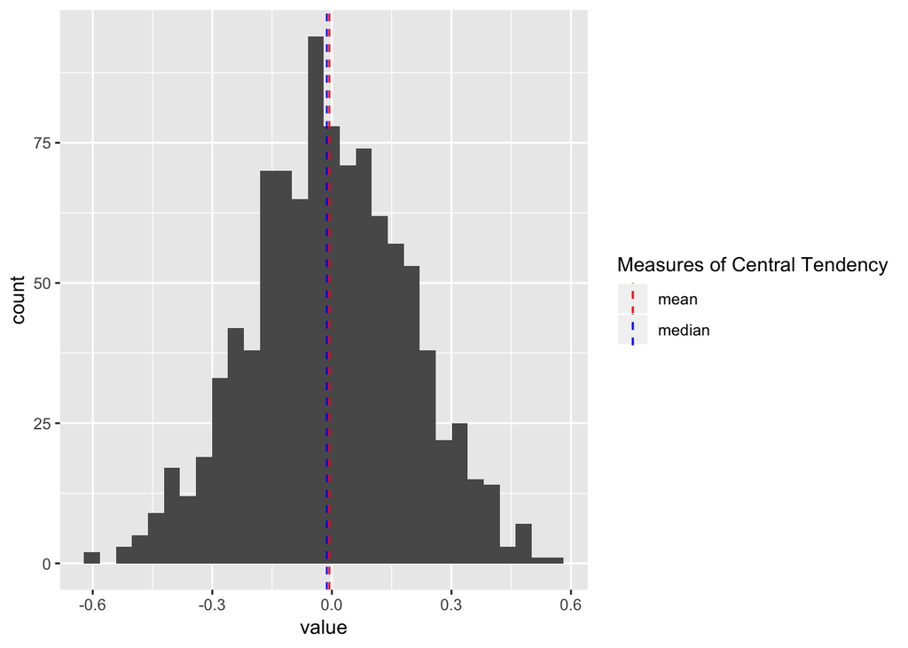

### Left skew

A left skewed shape occurs when data are clustered around a large value and mostly fall to the right of the mean (and typically the median, too). Left skewed data is also often referred to as negative skewed with a long left tail.

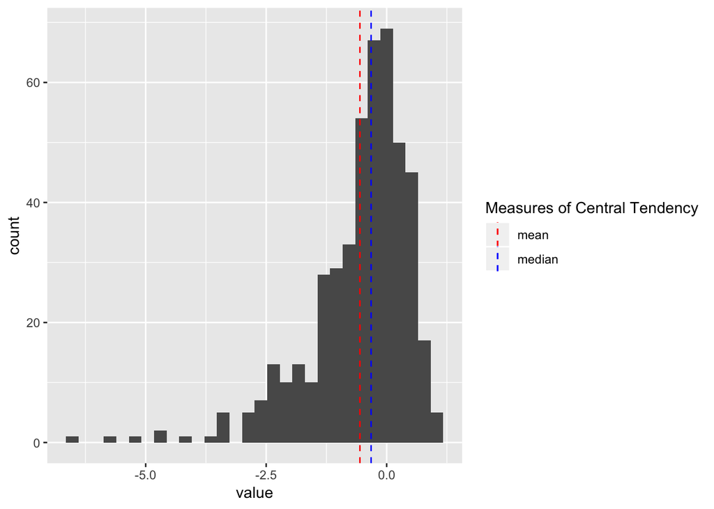

### Right skew

A right skew shape occurs when the data are clustered around a small value and most of the data (including the median) fall to the left of the mean. Right skewed data is also often referred to as positive skewed with a long right tail.

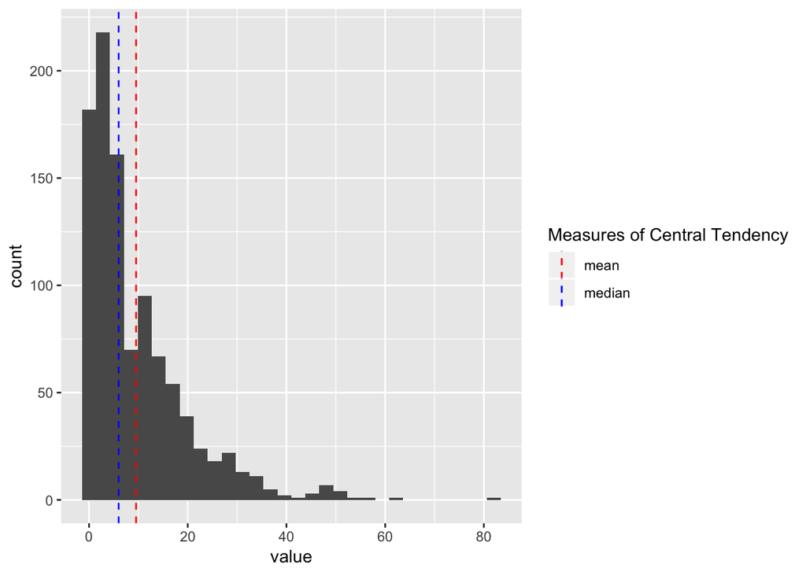

### Bimodal distribution

A Bimodal distribution shows two peaks of data. The peaks shows that there are two modes (two values that occur more frequently than any other) for the value you are plotting. These two peaks typically arise when your data set contains two distinct groups.  
When you see a bimodal distribution, consider breaking your data set into different groups to separate the peaks.

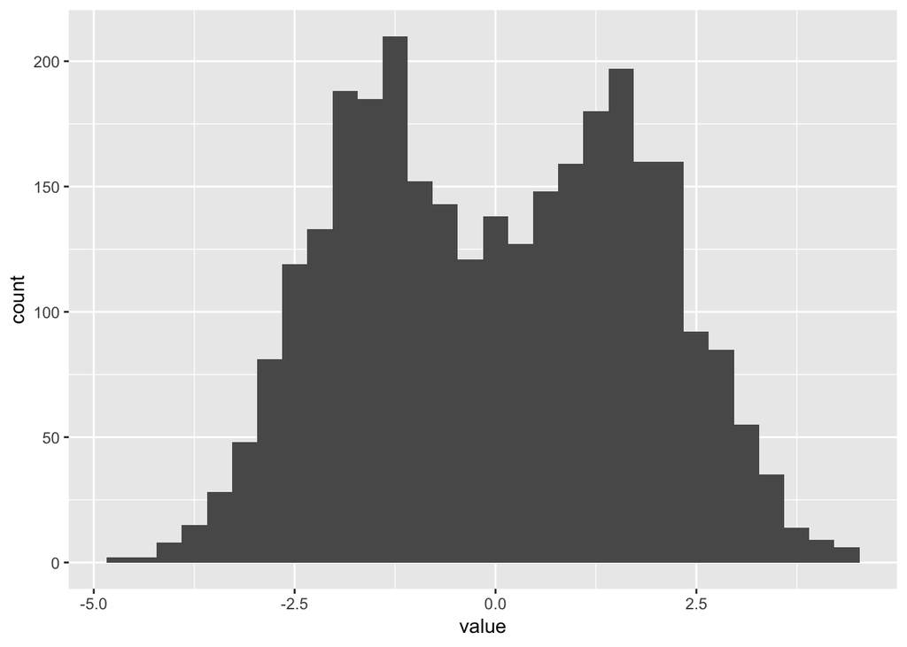

### Comb distribution

The Comb distribution alternates between high and low peaks. A comb shape can be caused by rounding numbers. Common examples of rounding that create comb distributions include: rounding temperatures, height, or age to the nearest whole number.

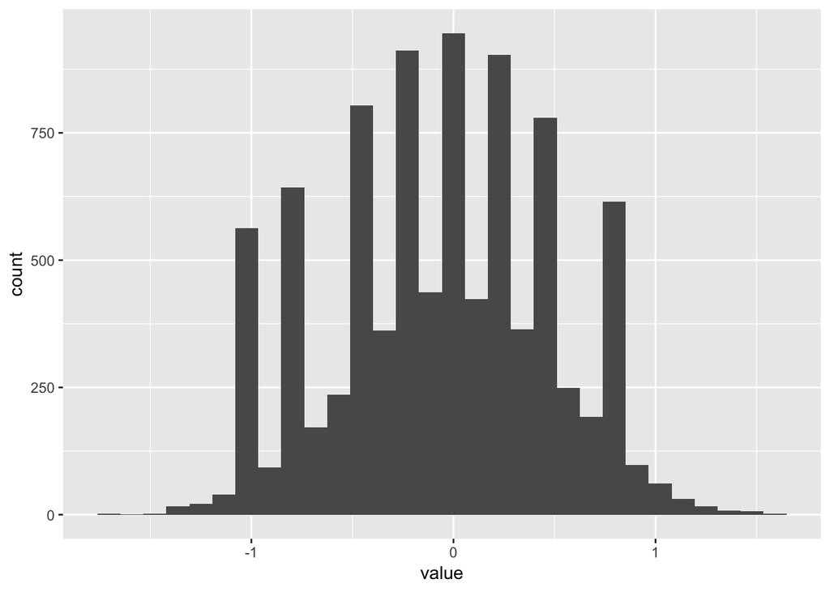

### Uniform distribution

A uniform distribution shows that the data are equally distributed: there are no clear peaks in the data.

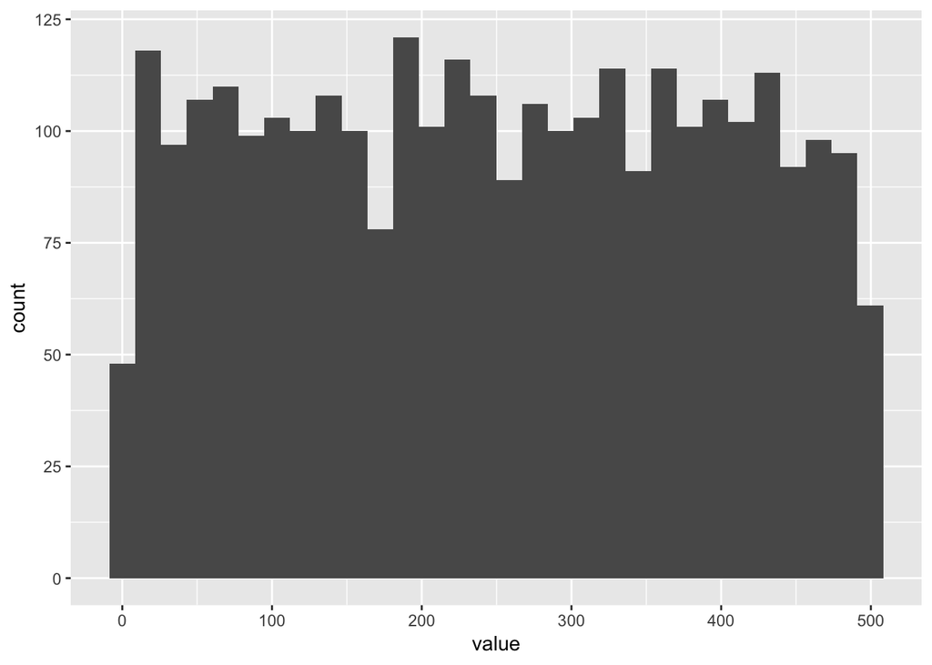